# Introduction

Samvel B. Gasparyan

https://gasparyan.co/

30 June, 2026

## `hce` package intro

### Background

[figure not shown]

The package supports the simulation and analysis of **univariate hierarchical composite endpoints (HCEs)**. The rationale for constructing a univariate endpoint, in contrast to the multivariate version of Generalized Pairwise Comparisons, which typically yields summary statistics rather than a single endpoint, is described in Gasparyan, Koch, and Brunner (Gasparyan, Koch, and Brunner 2026). The framework is broad: univariate HCEs can be derived from different outcome types, including time-to-event, continuous, and binary outcomes. However, it applies only to fixed follow-up designs without early dropout.

In this setting, several approaches can be used to derive a patient-level ordinal outcome, which is the essence of a univariate HCE. Gasparyan, Koch, and Brunner (Gasparyan, Koch, and Brunner 2026) derived the distribution for the setting with multiple time-to-event outcomes and a single continuous (or ordinal) outcome assessed at the end of follow-up; in that construction, the event times also contribute to the HCE. Accordingly, our definition of an HCE focuses on this setting. Although the theoretical distribution is not required for estimation, understanding the distribution remains important for interpreting summary statistics in greater detail and for avoiding the **Condorcet non-transitivity paradox** (De Condorcet et al. 2014).

These endpoints have been implemented in clinical trials across multiple therapeutic areas. For example, see Gasparyan et al. (2022) for an implementation in a COVID-19 setting and for practical considerations in constructing hierarchical composite endpoints. For chronic kidney disease (**CKD**) applications, see (Little et al. 2023; Heerspink et al. 2023; Kondo et al. 2024).

The primary analysis method is **win odds**. Other win statistics, including **win ratio** and **net benefit** (Dong et al. 2023), are also implemented when there is no censoring. Win odds relies on the **DeLong-DeLong-Clarke-Pearson** formula (DeLong, DeLong, and Clarke-Pearson 1988) for the variance of the win proportion and is based on the **Brunner-Munzel** test (Brunner and Munzel 2000). We also include the **Brunner-Konietschke** version (Brunner and Konietschke 2025) of the **Bamber** estimator (Bamber 1975) for the variance of the win proportion. In addition, the package provides **Wilson-type, range-preserving confidence intervals** for the win proportion and win odds, following Schüürhuis, Konietschke, and Brunner (Schüürhuis, Konietschke, and Brunner 2025).

The power and sample size formulas cover several classes of alternatives: `"shifted"`, `"ordered"`, and `"max"` for the maximum value of the standard deviation. All formulas are derived from Bamber (Bamber 1975). By default, **Noether’s formula** (Noether 1987) is used for shifted distributions. Additional discussion of power calculations for shifted distributions is available in (Gasparyan, Kowalewski, et al. 2021; Gasparyan, Kowalewski, and Koch 2022).

For reviews of HCE design in clinical trials, see (Gasparyan et al. 2022), (Gasparyan et al. 2023), and (Little et al. 2023). The **Basic Data Structure (BDS)**, which follows **Analysis Data Model (ADaM)** (CDISC 2009) principles for hierarchical composite endpoints, is described in Gasparyan et al. (2024). For visualization, the **maraca plot** (Karpefors, Lindholm, and Gasparyan 2023) can be used.

Stratified and adjusted win odds are calculated using **randomization-based covariate adjustment theory** (Koch et al. 1998); for a review, see (Gasparyan, Folkvaljon, et al. 2021).

Thresholds for pairwise comparisons involving the continuous component of the HCE are implemented according to the theory in Gasparyan, Koch, and Brunner (Gasparyan, Koch, and Brunner 2026).

All implementations are **rank-based**. For a methodological review, see (Brunner, Bathke, and Konietschke 2018).

### Setup

Load the package `hce` and check the version

```r
library(hce)
packageVersion("hce")
```

[output not shown]

For citing the package, run `citation("hce")` (Gasparyan 2026).

### Contents

List the functions and the datasets in the package

```r
ls("package:hce")
```

```
#>  [1] "ADET"        "ADLB"        "ADSL"        "COVID19"     "COVID19b"
#>  [6] "COVID19plus" "HCE1"        "HCE2"        "HCE3"        "HCE4"
#> [11] "HGLL"        "IWP"         "KHCE"        "as_formulae" "as_hce"
#> [16] "calcWINS"    "calcWO"      "dGLL"        "deltaWO"     "hGLL"
#> [21] "hce"         "minWO"       "pGLL"        "powerWO"     "propWINS"
#> [26] "qGLL"        "rGLL"        "regWO"       "rweibullGF"  "simHCE"
#> [31] "simKHCE"     "simORD"      "simTTE"      "sizeWO"      "sizeWR"
#> [36] "stratWO"     "summaryWO"
```

The package contains the following **Datasets**: use `data(package = "hce")` for the list of all datasets included in the package.

```r
HCE1; HCE2; HCE3; HCE4
COVID19; COVID19b; COVID19plus
ADET; ADLB; ADSL; KHCE
```

- **Simulated datasets**: `HCE1 - HCE4` contain two treatment groups and analysis values `AVAL` for a hierarchical composite endpoint.
- **COVID-19 datasets**: `COVID19`, `COVID19b`, and `COVID19plus` contain COVID-19 ordinal scale outcomes (Beigel et al. 2020; Kalil et al. 2021).
- **Synthetic kidney disease datasets**: `ADET` contains event-time data, `ADLB` contains laboratory data, and `ADSL` contains subject-level baseline characteristics. Based on these data, `KHCE` provides the derived kidney hierarchical composite endpoint for the same patients (Heerspink et al. 2023).

## In Brief

### Calculations

```r
calcWO()
calcWINS()
summaryWO()
regWO()
stratWO()
IWP()
```

The main functions for calculating the so-called win statistics—**win probability**, **win odds**, **win ratio**, and **net benefit**—are `calcWO()` for win odds and `calcWINS()` for all win statistics, including win odds. To summarize wins, losses, and ties, use `summaryWO()`, which also reports the win probability, win odds, and win ratio, together with the standard errors of the win probability and win odds. By default, all of these functions use the **DeLong-DeLong-Clarke-Pearson** formula (DeLong, DeLong, and Clarke-Pearson 1988) to estimate the standard error of the win probability and win odds.

In `calcWINS()`, the `SE_WP_Type` argument can be set to `unbiased` to use the **Brunner-Konietschke** version (Brunner and Konietschke 2025) of the **Bamber** estimator (Bamber 1975) for the variance of the win proportion, or to `biased` to use the **DeLong-DeLong-Clarke-Pearson** variance estimator, which is the same method used in `calcWO()` and may be biased in small samples. In the same function, the `CI_WP_Type` argument can be set to `Wilson` to obtain **Wilson-type, range-preserving confidence intervals** for the win proportion and win odds, following Schüürhuis, Konietschke, and Brunner (Schüürhuis, Konietschke, and Brunner 2025). The function `calcWINS()` also implements **Goodman-Kruskal’s gamma** (Goodman and Kruskal 1954, 1963). All reported statistics include confidence intervals.

The functions `regWO()` and `stratWO()` compute adjusted and stratified win odds, respectively, based on the **randomization-based covariate adjustment theory** developed in Koch et al. (Koch et al. 1998); for a review, see Gasparyan et al. (Gasparyan, Folkvaljon, et al. 2021).

In principle, all of these functions operate on ordinal outcomes when each patient contributes a single analysis value. Therefore, the input data should be at the patient level. Any patient-level dataset with a numeric analysis value can be used to calculate these statistics. In this setting, the use of win statistics is equivalent to ordinal analysis. Specifically, win odds corresponds to the classical **Mann-Whitney odds**, win ratio is the number of concordances divided by the number of discordances and can be derived from **Goodman-Kruskal’s gamma**, and net benefit corresponds to **Somers’ D C/R**. Therefore, any software that computes these statistics should produce the same results. For example, although the implementation here is fully rank-based, the estimate of **Goodman-Kruskal’s gamma** and its confidence interval agree with `DescTools::GoodmanKruskalGamma()` (Signorell 2025).

All calculations are rank-based and therefore computationally efficient. The basic building blocks are the **individual win proportions**, defined for each patient as the proportion of wins plus one-half of the proportion of ties. The function `IWP()` computes these individual win proportions for each patient in the dataset and returns an updated dataset with a new column. Any win-odds-related calculation can be based on these quantities (Gasparyan, Folkvaljon, et al. 2021).

### Univariate hierarchical composite endpoints

```r
hce()
as_hce()
```

The idea behind **univariate hierarchical composite endpoints** (Gasparyan, Koch, and Brunner 2026) is to derive a single ordinal outcome from multiple outcomes of different types, such as time-to-event, continuous, and binary outcomes, by prioritizing the most clinically important outcome for each patient. The resulting ordinal outcome can then be used to calculate win statistics.

To support this, the package provides helper functions for deriving `hce` objects from different types of outcomes. In particular, `hce()` and `as_hce()` check the structure of the input data and attempt to convert it to an `hce` object. Once this conversion is complete, that is, once the univariate HCE has been derived, the subsequent theory and analysis are the same as for any other ordinal outcome.

### Thresholds

```r
deltaWO()
```

The function `deltaWO()` calculates threshold-adjusted win odds (Gasparyan, Koch, and Brunner 2026).

### Simulations

```r
simORD()
simHCE()
simTTE()
simKHCE()
```

### Power and sample size

```r
powerWO()
sizeWO()
sizeWR()
minWO()
propWINS()
```

The functions `powerWO()`, `sizeWO()`, and `minWO()` provide tools for calculating **power**, **sample size**, and the **minimum detectable treatment effect** for win odds under different classes of alternatives: `"shifted"`, `"ordered"`, and `"max"`, where `"max"` refers to the maximum value of the standard deviation. All formulas are based on Bamber (Bamber 1975). For shifted distributions, the default is **Noether’s formula** (Noether 1987). See also (Gasparyan, Kowalewski, et al. 2021; Gasparyan, Kowalewski, and Koch 2022) for further discussion of shifted distributions. The function `sizeWR()` provides sample size calculations for the **win ratio** (Yu and Ganju 2022).

The function `propWINS()` is a convenient tool for deriving the proportions of **wins**, **losses**, and **ties** for each treatment group from the win odds and win ratio.

### Ordinal dominance graph and the maraca plot

```r
plot.hce()
```

A plot method for `hce` objects (created by `as_hce()`) to provide the ordinal dominance graph (Bamber 1975).

### Extras

```r
rweibullGF()
dGLL()
pGLL()
qGLL()
rGLL()
hGLL()
HGLL()
```

The **generalized log-logistic (GLL)** distributions arise as the marginal distributions of the **Weibull-Gamma frailty model**. For comparison, one can use `rweibullGF()`, which implements the random frailty formulation, and compare its output with the generalized log-logistic distribution functions: density `dGLL()`, distribution function `pGLL()`, quantile function `qGLL()`, random generation `rGLL()`, hazard function `hGLL()`, and cumulative hazard function `HGLL()`.

These distributions form the basis for constructing two-outcome hierarchical composite endpoints with death and hospitalization in the generalized illness-death model implemented in `simTTE()`.

### Helpers

```r
print.hce_results()
plot.hce_results()
as_formulae.formula()
```

To facilitate visualization and review of sample size and power calculations, `print()` and `plot()` methods are implemented for `hce_results` objects generated by the functions `powerWO()`, `sizeWO()`, and `minWO()`.

The function `as_formulae()` is an internal helper that decomposes formula objects into treatment, response, covariate, and grouping variables using the standardized names `TRTP`, `AVAL`, `COVAR`, and `GROUP`, respectively.

## `hce` Objects

### `hce()` Function

`hce` objects can be constructed using the helper function `hce()`, which has the following arguments:

```r
args("hce")
```

```
#> function (GROUP, TRTP, AVAL0 = NULL, PADY = NULL)
#> NULL
```

We see that the required arguments are `GROUP`, which specifies the clinically most important event of a patient to be included in the analysis, and `TRTP`, which specifies the (planned) treatment group of a patient (exactly two treatment groups should be present). Note that:

- The `hce` structure assumes that only one event per patient is present for the analysis, meaning that the resulting `hce` object created by the `hce()` function is a patient-level dataset. The function `hce()` does not select the clinically most important event of the patient but requires it to be already done when calling it.
- The argument `TRTP` should have exactly two levels.

Consider the following example of ordinal outcomes ‘I’, ‘II’, and ‘III’:

```r
set.seed(2022)
n <- 100
dat <- hce(GROUP = rep(x = c("I", "II", "III"), each = 100),
           TRTP = sample(x = c("Active", "Control"), size = n*3, replace = TRUE))
class(dat)
```

```
#> [1] "hce"        "data.frame"
```

This dataset has the appropriate structure of `hce` objects, but its class inherits from an object of class `data.frame`. This means that all functions available for data frames can be applied to `hce` objects, for example, the function `head()`:

```r
head(dat)
```

```
#>      TRTP GROUP PARAMN AVAL
#> 1 Control     I      1    1
#> 2  Active     I      1    1
#> 3 Control     I      1    1
#> 4  Active     I      1    1
#> 5  Active     I      1    1
#> 6 Control     I      1    1
```

We see that the dataset has a very specific structure. The column `PARAMN` shows how the function `hce()` generated the order of given events (it uses usual alphabetic order for the unique values in the `GROUP` column to determine the clinical importance of events):

```r
unique(dat[, c("GROUP", "PARAMN")])
```

```
#>     GROUP PARAMN
#> 1       I      1
#> 101    II      2
#> 201   III      3
```

In the class `hce`, higher values for the ordering mean clinically less important events. For example, death, which is the most important event, should always get the lowest ordinal value. If there is a need to specify the order of outcomes, then the `GROUP` argument can be provided as a factor with the levels specifying the necessary order:

```r
set.seed(2022)
n <- 100
GROUP = rep(x = c("I", "II", "III"), each = 100)
GROUP <- factor(GROUP, levels = c("III", "II", "I"))
dat <- hce(GROUP = GROUP,
           TRTP = sample(x = c("Active", "Control"), size = n*3, replace = TRUE))
unique(dat[, c("GROUP", "PARAMN")])
```

```
#>     GROUP PARAMN
#> 1       I      3
#> 101    II      2
#> 201   III      1
```

This means that the clinically most important event is ‘III’ instead of ‘I’. The argument `AVAL0` is meant to help in cases where we want to introduce sub-ordering within each `GROUP` category. For example, if two events in the group ‘I’ can be compared based on other parameters, then the `AVAL0` argument can be specified to take that into account.

Below we use the built-in data frame `HCE1` to construct an `hce` object. Before specifying the order of events, it is a good idea to check what are the unique events included in the `GROUP` column:

```r
data(HCE1)
unique(HCE1$GROUP)
```

```
#> [1] "C"    "TTE4" "TTE1" "TTE2" "TTE3"
```

Therefore, we can construct the following object using the `hce()` function:

```r
HCE <- hce(GROUP = factor(HCE1$GROUP, levels = c("TTE1", "TTE2", "TTE3", "TTE4", "C")),
           TRTP = HCE1$TRTP, AVAL0 = HCE1$AVAL0, PADY = 1080)
class(HCE)
```

```
#> [1] "adhce"      "hce"        "data.frame"
```

```r
head(HCE)
```

```
#>   TRTP GROUP  AVAL0 PARAMN    AVAL PADY GROUPN
#> 1    A     C  -2.21      5 5446.32 1080   5400
#> 2    P     C  17.06      5 5465.59 1080   5400
#> 3    A  TTE4 966.00      4 5286.00 1080   4320
#> 4    P  TTE4 352.00      4 4672.00 1080   4320
#> 5    A     C -12.45      5 5436.08 1080   5400
#> 6    P     C  44.62      5 5493.15 1080   5400
```

The object’s class is `adhce`, which inherits from `hce`. This design indicates that the object includes additional columns.

### Create an `hce` Object from a Data Frame

Consider the dataset `HCE1`, which is part of the package `hce`:

```r
data(HCE1, package = "hce")
class(HCE1)
```

```
#> [1] "data.frame"
```

```r
head(HCE1)
```

```
#>   ID TRTP GROUP GROUPN AVALT  AVAL0    AVAL PADY
#> 1  1    A     C   5400  1080  -2.21 5446.32 1080
#> 2  2    P     C   5400  1080  17.06 5465.59 1080
#> 3  3    A  TTE4   4320   966 966.00 5286.00 1080
#> 4  4    P  TTE4   4320   352 352.00 4672.00 1080
#> 5  5    A     C   5400  1080 -12.45 5436.08 1080
#> 6  6    P     C   5400  1080  44.62 5493.15 1080
```

This dataset has the appropriate structure of `hce` objects, but its class is `data.frame.` A generic way of coercing data structures to an `hce` object is to use the function `as_hce()`. This function performs checks (using an internal validator function) and creates an `hce` object from the given data structure (using an internal constructor function). If coercion is not possible, it will throw an error explaining the issue.

```r
dat1 <- as_hce(HCE2)
str(dat1)
```

```
#> Classes 'adhce', 'hce' and 'data.frame': 1000 obs. of  9 variables:
#>  $ ID    : int  1 2 3 4 5 6 7 8 9 10 ...
#>  $ TRTP  : chr  "A" "P" "A" "P" ...
#>  $ GROUP : Factor w/ 5 levels "TTE1","TTE2",..: 1 5 5 1 2 3 5 2 1 5 ...
#>  $ GROUPN: num  1080 5400 5400 1080 2160 3240 5400 2160 1080 5400 ...
#>  $ AVALT : num  120 1080 1080 577 782 985 1080 293 313 1080 ...
#>  $ AVAL0 : num  120 3.35 22.8 577 782 ...
#>  $ AVAL  : num  1200 5461 5480 1657 2942 ...
#>  $ PADY  : num  1080 1080 1080 1080 1080 1080 1080 1080 1080 1080 ...
#>  $ PARAMN: num  1 5 5 1 2 3 5 2 1 5 ...
```

### Simulate `hce` Objects Using `simHCE()`

To simulate values from a hierarchical composite endpoint, we use the function `simHCE()`, which has the following arguments:

```r
args("simHCE")
```

```
#> function (n, n0 = n, TTE_A, TTE_P, CM_A, CM_P, CSD_A = 1, CSD_P = CSD_A,
#>     fixedfy = 1, yeardays = 360, pat = 100, shape = 1, theta = 1,
#>     logC = FALSE, seed = NULL, dec = 2, all_data = FALSE)
#> NULL
```

- The vector arguments `TTE_A` and `TTE_P` specify the event rates per year for time-to-event outcomes in the active and control groups, respectively. The function assumes a Weibull survival function with the same shape parameter for simulating all time-to-event outcomes in both treatment groups (by default `shape = 1`, which assumes an exponential survival function). These two vectors should have the same length, which indicates the number of time-to-event outcomes.
- By default, the event rates are presented per 100 patient-years (`pat = 100`), which can be changed using the argument `pat`. The function simulates event times in days, and the `yeardays = 360` argument can be used to change the number of days in a year (e.g., 365 or 365.25).
- The function simulates events during a fixed follow-up period only, and the `fixedfy` argument can be used to change the length of the follow-up (in years).
- The function simulates the continuous outcome from a normal (default) or log-normal (if `logC = TRUE`) distribution with given means and standard deviations for two treatment groups.

```r
Rates_A <- c(1.72, 1.74, 0.58, 1.5, 1)
Rates_P <- c(2.47, 2.24, 2.9, 4, 6)
dat3 <- simHCE(n = 2500, n0 = 1500, TTE_A = Rates_A,
               TTE_P = Rates_P,
               CM_A = -3, CM_P = -6,
               CSD_A = 16, CSD_P = 15,
               fixedfy = 3, seed = 2023)
```

```r
class(dat3)
```

```
#> [1] "adhce"      "hce"        "data.frame"
```

```r
head(dat3)
```

```
#>   ID TRTP GROUP GROUPN AVALT  AVAL0    AVAL seed PADY PARAMN
#> 1  1    A     C   6480  1080  -9.32 6526.85 2023 1080      6
#> 2  2    A     C   6480  1080   0.11 6536.28 2023 1080      6
#> 3  3    A     C   6480  1080  27.06 6563.23 2023 1080      6
#> 4  4    A     C   6480  1080  -4.78 6531.39 2023 1080      6
#> 5  5    A  TTE2   2160   390 390.00 2550.00 2023 1080      2
#> 6  6    A     C   6480  1080   4.56 6540.73 2023 1080      6
```

## Generics for `hce` Objects

As we see, the function `simHCE()` creates an object of type `hce`, which inherits from the built-in class `data.frame`. We can check all implemented methods for this new class as follows:

```r
methods(class = "hce")
```

```
#> [1] calcWINS  calcWO    plot      summaryWO
#> see '?methods' for accessing help and source code
```

The function `calcWO()` calculates the win odds and its confidence interval, while `summaryWO()` provides a more detailed calculation of win odds, including the number of wins, losses, and ties by `GROUP` categories.

```r
HCE <- hce(GROUP = factor(HCE3$GROUP, levels = c("TTE1", "TTE2", "TTE3", "TTE4", "C")),
           TRTP = HCE3$TRTP, AVAL0 = HCE3$AVAL0, PADY = 1080)
calcWO(HCE)
```

```
#>         WO     LCL      UCL         SE WOnull alpha       Pvalue       WP
#> 1 1.332829 1.15078 1.543678 0.07493202      1  0.05 0.0001014229 0.571336
#>      LCL_WP    UCL_WP      SE_WP     SD_WP    N
#> 1 0.5353673 0.6073047 0.01835169 0.5803314 1000
```

```r
calcWINS(HCE)
```

```
#> $summary
#>      WIN   LOSS TIE  TOTAL Pties
#> 1 142824 107156  20 250000 8e-05
#>
#> $WP
#>         WP       LCL       UCL       Pvalue
#> 1 0.571336 0.5353673 0.6073047 0.0001014229
#>
#> $NetBenefit
#>   NetBenefit       LCL       UCL       Pvalue
#> 1   0.142672 0.0707347 0.2146093 0.0001014229
#>
#> $WO
#>         WO     LCL      UCL       Pvalue
#> 1 1.332829 1.15078 1.543678 0.0001014229
#>
#> $WR1
#>         WR     LCL1     UCL1     Pvalue1
#> 1 1.332861 1.150793 1.543733 0.000125974
#>
#> $WR2
#>         WR     LCL2     UCL2      Pvalue2
#> 1 1.332861 1.155092 1.537987 8.351682e-05
#>
#> $gamma
#>       gamma        LCL       UCL      Pvalue
#> 1 0.1426834 0.07074057 0.2146263 0.000101418
#>
#> $SE
#>        WP_SE NetBenefit_SE  logWR_SE1  logWR_SE2   gamma_SE
#> 1 0.01835169    0.03670338 0.07493804 0.07303552 0.03670621
#>
#> $ref
#> [1] "A vs P"
#>
#> $Input
#>   alpha WOnull
#> 1  0.05      1
```

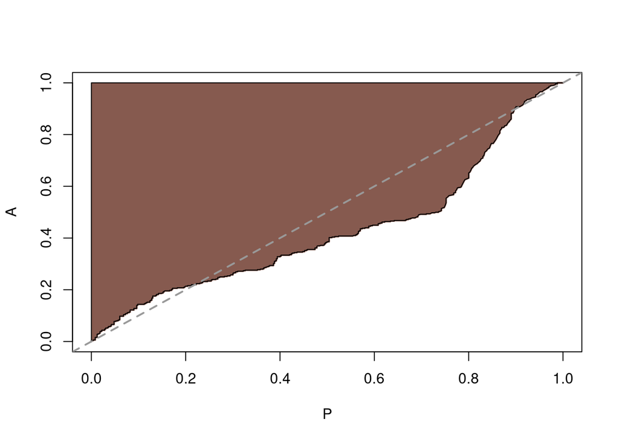

```r
HCE$TRTP <- factor(HCE$TRTP, levels = c("P", "A"))
plot(HCE, fill = TRUE, col = "#865A4F", type = 'l', lwd = 2)
abline(a = 0, b = 1, lwd = 2, col = "#999999", lty = 2)
```

To check the generic functions available for the `adhce` class by running the following command:

```r
methods(class = "adhce")
```

```
#> [1] deltaWO   summaryWO
#> see '?methods' for accessing help and source code
```

The main difference between `summaryWO.hce()` and `summaryWO.adhce()` is that `summaryWO.adhce()` also provides a group-wise summary, in addition to the overall summary:

```r
summaryWO(HCE)
```

```
#> $summary
#>   TRTP    WIN   LOSS TIE  TOTAL        WR        WO
#> 1    A 142824 107156  20 250000 1.3328605 1.3328294
#> 2    P 107156 142824  20 250000 0.7502661 0.7502835
#>
#> $summary_by_GROUP
#>    TRTP GROUP    WIN  LOSS TIE  TOTAL
#> 1     A  TTE1   2473 39525   2  42000
#> 2     P  TTE1   2985 29513   2  32500
#> 3     A  TTE2   6847 22648   5  29500
#> 4     P  TTE2  13857 45138   5  59000
#> 5     A  TTE3  13251 16745   4  30000
#> 6     P  TTE3  13356 25140   4  38500
#> 7     A  TTE4   9056  6443   1  15500
#> 8     P  TTE4  15383 19616   1  35000
```

[output cut: 24 more lines]

An important addition to `summaryWO.adhce()` is the `cumsummary_by_GROUP` output, which reports cumulative wins, losses, and ties as outcomes are added sequentially according to the priority order:

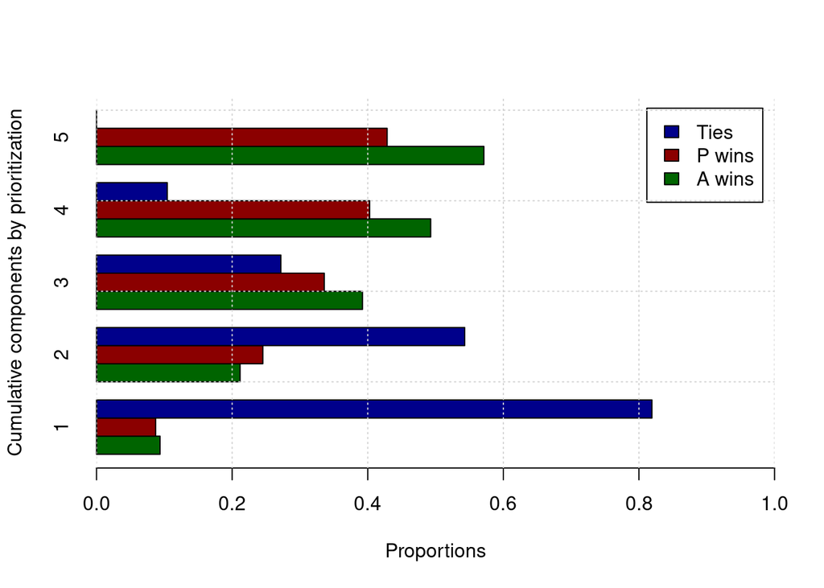

```r
res0 <- summaryWO(HCE, ref = "P")
res <- res0$cumsummary_by_GROUP
barplot(PROP ~ WINS + GROUPN, data = res,
col = c("darkgreen", "darkred", "darkblue"),
xlab = "Proportions", xlim = c(0, 1),
ylab = "Cumulative components by prioritization",
legend.text = unique(res$WINS), beside = TRUE, horiz = TRUE)
grid()
```

## References

Bamber, Donald. 1975. “The Area Above the Ordinal Dominance Graph and the Area Below the Receiver Operating Characteristic Graph.” *Journal of Mathematical Psychology* 12 (4): 387–415. https://doi.org/10.1016/0022-2496(75)90001-2.

Beigel, John H, Kay M Tomashek, Lori E Dodd, Aneesh K Mehta, Barry S Zingman, Andre C Kalil, Elizabeth Hohmann, et al. 2020. “Remdesivir for the Treatment of Covid-19.” *New England Journal of Medicine* 383 (19): 1813–26. https://doi.org/10.1056/NEJMoa2007764.

Brunner, Edgar, Arne C Bathke, and Frank Konietschke. 2018. *Rank and Pseudo-Rank Procedures for Independent Observations in Factorial Designs*. Springer. http://doi.org/10.1007/978-3-030-02914-2.

Brunner, Edgar, and Frank Konietschke. 2025. “An Unbiased Rank-Based Estimator of the Mann–Whitney Variance Including the Case of Ties.” *Statistical Papers* 66 (1): 20. http://doi.org/10.1007/s00362-024-01635-0.

Brunner, Edgar, and Ullrich Munzel. 2000. “The Nonparametric Behrens-Fisher Problem: Asymptotic Theory and a Small-Sample Approximation.” *Biometrical Journal: Journal of Mathematical Methods in Biosciences* 42 (1): 17–25. https://doi.org/10.1002/(SICI)1521-4036(200001)42:1%3C17::AID-BIMJ17%3E3.0.CO;2-U.

CDISC, Clinical Data Interchange Standards Consortium. 2009. “ADaM.” https://www.cdisc.org/standards/foundational/adam.

De Condorcet, Nicolas et al. 2014. *Essai Sur l’application de l’analyse à La Probabilité Des décisions Rendues à La Pluralité Des Voix*. Cambridge University Press.

DeLong, Elizabeth R, David M DeLong, and Daniel L Clarke-Pearson. 1988. “Comparing the Areas Under Two or More Correlated Receiver Operating Characteristic Curves: A Nonparametric Approach.” *Biometrics* 44 (3): 837–45. https://doi.org/10.2307/2531595.

Dong, Gaohong, Bo Huang, Johan Verbeeck, Ying Cui, James Song, Margaret Gamalo-Siebers, Duolao Wang, et al. 2023. “Win Statistics (Win Ratio, Win Odds, and Net Benefit) Can Complement One Another to Show the Strength of the Treatment Effect on Time-to-Event Outcomes.” *Pharmaceutical Statistics* 22 (1): 20–33. https://doi.org/10.1002/pst.2251.

Gasparyan, Samvel B. 2026. *hce: Design and Analysis of Hierarchical Composite Endpoints*. *CRAN: The Comprehensive R Archive Network, R Package, Version 0.9.5*. https://doi.org/10.32614/CRAN.package.hce.

Gasparyan, Samvel B, Joan Buenconsejo, Elaine K Kowalewski, Jan Oscarsson, Olof F Bengtsson, Russell Esterline, Gary G Koch, Otavio Berwanger, and Mikhail N Kosiborod. 2022. “Design and Analysis of Studies Based on Hierarchical Composite Endpoints: Insights from the DARE-19 Trial.” *Therapeutic Innovation & Regulatory Science* 56 (5): 785–94. https://doi.org/10.1007/s43441-022-00420-1.

Gasparyan, Samvel B, Folke Folkvaljon, Olof Bengtsson, Joan Buenconsejo, and Gary G Koch. 2021. “Adjusted Win Ratio with Stratification: Calculation Methods and Interpretation.” *Statistical Methods in Medical Research* 30 (2): 580–611. https://doi.org/10.1177/0962280220942558.

Gasparyan, Samvel B, Gary G Koch, and Edgar Brunner. 2026. “The Univariate Distribution of Hierarchical Composite Endpoints and the Condorcet Non-Transitivity Paradox.” *Biometrical Journal* 68 (3): e70140.

Gasparyan, Samvel B, Elaine K Kowalewski, Joan Buenconsejo, and Gary G Koch. 2023. “Hierarchical Composite Endpoints in COVID-19: The DARE-19 Trial.” In *Case Studies in Innovative Clinical Trials*, 95–148. Chapman; Hall/CRC. https://doi.org/10.1201/9781003288640-7.

Gasparyan, Samvel B, Elaine K Kowalewski, Folke Folkvaljon, Olof Bengtsson, Joan Buenconsejo, John Adler, and Gary G Koch. 2021. “Power and Sample Size Calculation for the Win Odds Test: Application to an Ordinal Endpoint in COVID-19 Trials.” *Journal of Biopharmaceutical Statistics* 31 (6): 765–87. https://doi.org/10.1080/10543406.2021.1968893.

Gasparyan, Samvel B, Elaine K Kowalewski, and Gary G Koch. 2022. “Comments on ‘Sample Size Formula for a Win Ratio Endpoint’ by RX Yu and j. Ganju.” *Statistics in Medicine* 41 (14): 2688–90. https://doi.org/10.1002/sim.9379.

Gasparyan, Samvel B, Nicole Major, Christoffer Bäckberg, Srivathsa Ravikiran, Parag Wani, Martin Karpefors, and Samvel B Gasparyan. 2024. “Basic Data Structure for Hierarchical Composite Endpoints: An Application to Kidney Disease Trials.” *Journal of the Society for Clinical Data Management* 4 (1). https://doi.org/10.47912/jscdm.265.

Goodman, Leo A, and William H Kruskal. 1954. “Measures of Association for Cross Classifications.” *Journal of the American Statistical Association* 49 (268): 732–64.

———. 1963. “Measures of Association for Cross Classifications III: Approximate Sampling Theory.” *Journal of the American Statistical Association* 58 (302): 310–64.

Heerspink, Hiddo L, Niels Jongs, Patrick Schloemer, Dustin J Little, Meike Brinker, Christoph Taso, Martin Karpefors, et al. 2023. “Development and Validation of a New HCE for Clinical Trials of Kidney Disease Progression.” *Journal of the American Society of Nephrology* 34 (12): 2025–38. https://doi.org/10.1681/ASN.0000000000000243.

Kalil, Andre C, Thomas F Patterson, Aneesh K Mehta, Kay M Tomashek, Cameron R Wolfe, Varduhi Ghazaryan, Vincent C Marconi, et al. 2021. “Baricitinib Plus Remdesivir for Hospitalized Adults with Covid-19.” *New England Journal of Medicine* 384 (9): 795–807. https://doi.org/10.1056/NEJMoa2031994.

Karpefors, Martin, Daniel Lindholm, and Samvel B Gasparyan. 2023. “The Maraca Plot: A Novel Visualization of Hierarchical Composite Endpoints.” *Clinical Trials* 20 (1): 84–88. https://doi.org/10.1177/17407745221134949.

Koch, Gary G, Catherine M Tangen, Jin-Whan Jung, and Ingrid A Amara. 1998. “Issues for Covariance Analysis of Dichotomous and Ordered Categorical Data from Randomized Clinical Trials and Non-Parametric Strategies for Addressing Them.” *Statistics in Medicine* 17 (15-16): 1863–92. https://doi.org/10.1002/(sici)1097-0258(19980815/30)17:15/16%3C1863::aid-sim989%3E3.0.co;2-m.

Kondo, Toru, Pardeep S Jhund, Samvel B Gasparyan, Mingming Yang, Brian L Claggett, Finnian R McCausland, Paolo Tolomeo, et al. 2024. “A Hierarchical Kidney Outcome Using Win Statistics in Patients with Heart Failure from the DAPA-HF and DELIVER Trials.” *Nature Medicine* 30 (5): 1432–39. https://doi.org/10.1038/s41591-024-02941-8.

Little, Dustin J, Samvel B Gasparyan, Patrick Schloemer, Niels Jongs, Meike Brinker, Martin Karpefors, Christoph Taso, et al. 2023. “Validity and Utility of a Hierarchical Composite Endpoint for Clinical Trials of Kidney Disease Progression: A Review.” *Journal of the American Society of Nephrology* 34 (12): 1928–35. https://doi.org/10.1681/ASN.0000000000000244.

Noether, Gottfried E. 1987. “Sample Size Determination for Some Common Nonparametric Tests.” *Journal of the American Statistical Association* 82 (398): 645–47. https://doi.org/10.1080/01621459.1987.10478478.

Schüürhuis, Stephen, Frank Konietschke, and Edgar Brunner. 2025. “A New Approach to the Nonparametric Behrens–Fisher Problem with Compatible Confidence Intervals.” *Biometrical Journal* 67 (6). https://doi.org/10.1002/bimj.70096.

Signorell, Andri. 2025. *DescTools: Tools for Descriptive Statistics*. https://doi.org/10.32614/CRAN.package.DescTools.

Yu, Ron Xiaolong, and Jitendra Ganju. 2022. “Sample Size Formula for a Win Ratio Endpoint.” *Statistics in Medicine* 41 (6): 950–63. https://doi.org/10.1002/sim.9297.